# CIS3521 B Final Project: Mangrove Tree Data Analysis

## 4.5 Percent Stacked Bar Chart of `site` and `om_percent`

The higher the amount of organic matter a plan has, the higher its Carbon and Nitrogen content will be. As such, by measuring the organic matter density of each site, we can determine each sites nutrient potential relative to the other sites. We can see that the sites `LOB` and `MON` have the highest nutrient potential, as their average OM% is greater than or equal to 66% of all `om_percent` measurements taken.

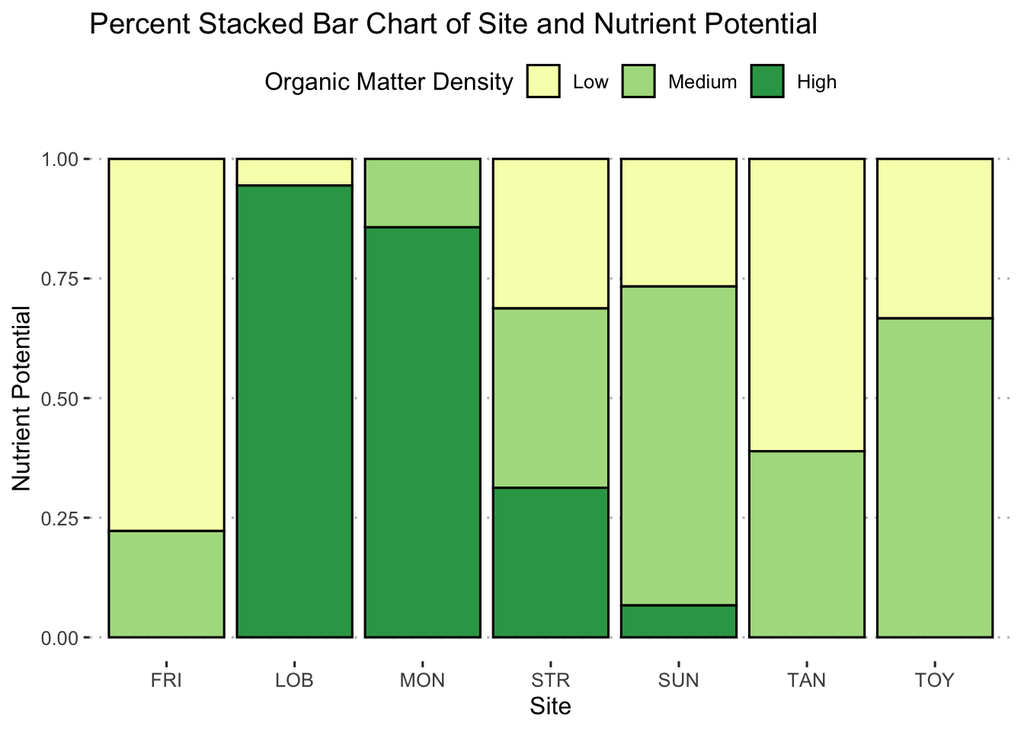

```r
plant_om_sum2 <- plant_material_samples_4 |>
    summarize(
        mean_om_p = mean(om_percent, na.rm = TRUE),
        sd_om_p = sd(om_percent, na.rm = TRUE),
        .by = site
    )

plant_om_bar_3 <- plant_material_samples_4 |>
  filter(!is.na(om_percent) & !is.na(site)) |>
  mutate(
    om_density = case_when(
      om_percent >= quantile(om_percent, 0.66) ~ 'High',
      om_percent >= quantile(om_percent, 0.33) ~ 'Medium',
      TRUE ~ 'Low'
    ),
    om_density = factor(om_density, levels = c("Low", "Medium", "High" ))
  ) |>
  ggplot(
    aes(
      x = site,
      fill = om_density
    )
  ) +
  geom_bar(
    position = 'fill',
    color = 'black'
  ) +
  theme_pubclean()+
  scale_fill_brewer(palette = 'YlGn') +
  labs(
    title = 'Percent Stacked Bar Chart of Site and Nutrient Potential',
    x = 'Site',
    y = 'Nutrient Potential',
    fill = "Organic Matter Density"
  )

plant_om_bar_3
```

# 5. Statisical Tests

## 5.1 Kruskal-Wallace Test

It’s evident in our graphs that `om_percent` differs across sites. We will run a Kruskal-Wallace test to confirm how significant this difference across sites is:

```r
k_test <- kruskal.test(om_percent ~ site, data = plant_material_samples_4)

print(k_test)
```

```
    Kruskal-Wallis rank sum test

data:  om_percent by site
Kruskal-Wallis chi-squared = 70.634, df = 6, p-value = 3.031e-13
```

### Our hypotheses are:

- $H_0$: The distribution of organic matter percentage is the same across all sites.
- $H_a$: The distribution of organic matter percentage is not equal across all sites.

The $p$-value is $3.031 \times 10^{-13} < 0.05 = \alpha$. Therefore, we reject the null hypothesis and conclude that there is significant evidence that organic matter percentage differs across the sampling sites.

## 5.2 Rank-Sum Test

Now, to use another non-parametic test that works across two categorical variables, we will use the Wilcoxon Rank-Sum test. It seemed in our graphs that there was not a strong relationship between species and OM%, so we will test to see how accurate that observation is:

```r
rs_test <- wilcox.test(om_percent ~ species, data = plant_material_samples_4)

print(rs_test)
```

```
    Wilcoxon rank sum test with continuity correction

data:  om_percent by species
W = 1598, p-value = 0.2301
alternative hypothesis: true location shift is not equal to 0
```

### Our hypotheses are:

- $H_0$: The distribution of organic matter percentage is the same across both species.
- $H_a$: The distribution of organic matter percentage is not equal across both species.

The $p$-value is $0.2301 > 0.05 = \alpha$. Therefore, we fail to reject the null hypothesis and conclude that there is not significant evidence that organic matter percentage differs between the two species.

# 6. Conclusion

We found that there is significant evidence of Organic Matter % differing across sites, and that there is not significant evidence of Organic Matter % differing across species. In other words, Organic Matter content of Mangrove tree samples differs across environments. With higher Organic Matter comes higher nutrient potential for plants in the form of Carbon and Nitrogen.

The limitations of this study included the lack of lab-tested C% and N% results. In this Capstone project, these values were derived from OM% using a formula. Since formulas were used, a linear relationship between these values is inevitable. With lab-tested results, we could have analyzed the relationship between C%, N%, and OM% in a more meaningful way.

Another limitation of our study was the lack of normal distribution in our data. Since our plant sampling data was not normally distributed, we could not effectively test our hypotheses using stronger statistical tests that require normal distribution such as the parametric tests, t-test and ANOVA.

It would be worth studying the environment of sampling sites with high OM% v.s. those of low OM% for potential future research, as when the difference in their environments can be found, it will provide clues as to the healthiest circumstances for Mangrove trees.